# Lab assignment 3

Maxim Holovin, Yaropolk Kalmyuk, Mykhailo Rykhalskyi

## Work breakdown:

Mykhailo Rykhalskyi - task 1  
Maxim Holovin - task 2  
Yaropolk Kalmyuk - task 3

# Part I: Parameter estimation

## Task 1

We are estimating the parameter θ (where mean μ=θ) of an Exponential distribution. We will test four different methods for constructing confidence intervals by running simulations. We will vary the sample size n and confidence level (1−α) to see how often each interval actually captures the true parameter (Coverage Probability) and how wide the intervals are (Precision). Our team id number is 23.

```r
# SETUP

library(ggplot2)

id_num <- 23
theta <- id_num / 10
lambda <- 1 / theta
m <- 10000

alphas <- c(0.1, 0.05, 0.01)
n_sizes <- c(10, 50, 100, 1000)

results <- data.frame()

# Helper function to calculate coverage and length
calc_metrics <- function(L, U, true_param) {
  cov <- mean((true_param >= L) & (true_param <= U))
  len <- mean(U - L)
  return(c(cov, len))
}

print(paste("Simulation initialized for Theta =", theta))
```

```
## [1] "Simulation initialized for Theta = 2.3"
```

### 1. Method 1: Exact Distribution (Chi-Squared)

This method utilizes the property that the sum of independent exponential variables follows a Gamma distribution. Specifically, the sample mean $\overline{X}$ and the parameter $\theta$ can be expressed with a Chi-squared distribution with $2n$ degrees of freedom.

$$\quad \frac{2n\overline{X}}{\theta} \sim \chi^2_{2n}$$

To find the $1-\alpha$ confidence interval, we set up:

$$P\left( \chi^2_{\alpha/2, 2n} \le \frac{2n\overline{X}}{\theta} \le
\chi^2_{1-\alpha/2, 2n} \right) = 1 - \alpha$$

By inverting the inequality to isolate $\theta$, we obtain the confidence interval:

$$\left[ \frac{2n\overline{X}}{\chi^2_{1-\alpha/2, 2n}}, \quad
\frac{2n\overline{X}}{\chi^2_{\alpha/2, 2n}} \right]$$

```r
# METHOD 1: EXACT (CHI-SQUARED)
set.seed(23)

for (n in n_sizes) {
  # Generate data (rows = sims, cols = sample size)
  data <- matrix(rexp(n * m, rate = lambda), nrow = m, ncol = n)
  x_bar <- rowMeans(data)

  for (alpha in alphas) {
    # Chi-square Quantiles
    q_low <- qchisq(alpha/2, df = 2*n)
    q_high <- qchisq(1 - alpha/2, df = 2*n)

    # Interval Calculation
    L <- (2 * n * x_bar) / q_high
    U <- (2 * n * x_bar) / q_low

    # Evaluate
    stats <- calc_metrics(L, U, theta)
    results <- rbind(results, data.frame(n=n, alpha=alpha, Method="1. Exact",
                                         Cov=stats[1], Len=stats[2]))
  }
}
```

### 2. Method 2: Normal Approximation (Known Variance)

This method assumes the Central Limit Theorem holds and calculates the interval as if the population variance ($\sigma^2 = \theta^2$) were known.

$$Z = \frac{\overline{X} - \theta}{\theta/\sqrt{n}} \sim \mathcal{N}(0, 1)$$

The resulting confidence interval is:

$$\left[ \overline{X} - z_{1-\alpha/2}\frac{\theta}{\sqrt{n}}, \quad
\overline{X} + z_{1-\alpha/2}\frac{\theta}{\sqrt{n}} \right]$$

```r
# METHOD 2: NORMAL (KNOWN THETA)
set.seed(23)

for (n in n_sizes) {
  data <- matrix(rexp(n * m, rate = lambda), nrow = m, ncol = n)
  x_bar <- rowMeans(data)

  for (alpha in alphas) {
    z <- qnorm(1 - alpha/2)

    margin <- z * (theta / sqrt(n))
    L <- x_bar - margin
    U <- x_bar + margin

    stats <- calc_metrics(L, U, theta)
    results <- rbind(results, data.frame(n=n, alpha=alpha, Method="2. Norm(Known)",
                                         Cov=stats[1], Len=stats[2]))
  }
}
```

### 3. Method 3: Normal Approximation

To remove the dependence on the unknown $\theta$ in the standard error term of Method 2, we start with the inequality:

$$|\overline{X} - \theta| \le z_{1-\alpha/2} \frac{\theta}{\sqrt{n}}$$

Let $k = \frac{z_{1-\alpha/2}}{\sqrt{n}}$. We solve for $\theta$:

$$\begin{aligned}
-k\theta &\le \overline{X} - \theta \le k\theta \\
\theta - k\theta &\le \overline{X} \le \theta + k\theta \\
\theta(1 - k) &\le \overline{X} \le \theta(1 + k)
\end{aligned}$$

Inverting for $\theta$ gives the interval:

$$\left[ \frac{\overline{X}}{1 + \frac{z_{1-\alpha/2}}{\sqrt{n}}}, \quad
\frac{\overline{X}}{1 - \frac{z_{1-\alpha/2}}{\sqrt{n}}} \right]$$

```r
# METHOD 3: NORMAL (SOLVED INEQUALITY)
set.seed(23)

for (n in n_sizes) {
  data <- matrix(rexp(n * m, rate = lambda), nrow = m, ncol = n)
  x_bar <- rowMeans(data)

  for (alpha in alphas) {
    z <- qnorm(1 - alpha/2)
    k <- z / sqrt(n)

    # Interval Calculation
    L <- x_bar / (1 + k)
    U <- x_bar / (1 - k)

    stats <- calc_metrics(L, U, theta)
    results <- rbind(results, data.frame(n=n, alpha=alpha, Method="3. Norm(Solved)",
                                         Cov=stats[1], Len=stats[2]))
  }
}
```

### 4. Method 4: Student’s t-distribution

This is the standard asymptotic approach when the variance is unknown. We estimate the population standard deviation $\sigma$ using the sample standard deviation $s$.

$$T = \frac{\overline{X} - \theta}{s/\sqrt{n}} \sim t_{n-1}$$

The confidence interval is:

$$\left[ \overline{X} - t_{n-1, 1-\alpha/2}\frac{s}{\sqrt{n}}, \quad
\overline{X} + t_{n-1, 1-\alpha/2}\frac{s}{\sqrt{n}} \right]$$

```r
# METHOD 4: STUDENT'S T
set.seed(23)

for (n in n_sizes) {
  data <- matrix(rexp(n * m, rate = lambda), nrow = m, ncol = n)
  x_bar <- rowMeans(data)
  s_sd <- apply(data, 1, sd)

  for (alpha in alphas) {
    t_val <- qt(1 - alpha/2, df = n - 1)

    # Interval Calculation
    margin <- t_val * (s_sd / sqrt(n))
    L <- x_bar - margin
    U <- x_bar + margin

    stats <- calc_metrics(L, U, theta)
    results <- rbind(results, data.frame(n=n, alpha=alpha, Method="4. Student-t",
                                         Cov=stats[1], Len=stats[2]))
  }
}
```

### Results Comparison

```r
library(knitr)

colnames(results)[which(names(results) %in% c("Coverage", "Cov"))] <- "Cov"
colnames(results)[which(names(results) %in% c("AvgLength", "Length", "Len"))] <- "Len"

clean_results <- results
colnames(clean_results)[which(names(clean_results) %in% c("Coverage", "Cov"))] <- "Cov"
colnames(clean_results)[which(names(clean_results) %in% c("AvgLength", "Length", "Len"))] <- "Len"

if (!requireNamespace("knitr", quietly = TRUE)) install.packages("knitr")
library(knitr)

options(max.print = 100000)

results_sorted <- clean_results[order(clean_results$n, clean_results$Method), ]

unique_alphas <- sort(unique(results_sorted$alpha), decreasing = TRUE)

for (curr_alpha in unique_alphas) {

  conf_level <- (1 - curr_alpha) * 100

  sub_table <- subset(results_sorted, alpha == curr_alpha)

  rownames(sub_table) <- NULL

  cat("\n\n")
  cat(paste("### Results for Alpha =", curr_alpha, "(", conf_level, "% Confidence )"))
  cat("\n")

  print(kable(sub_table, digits = 4, row.names = FALSE))
}
```

```
##
##
## ### Results for Alpha = 0.1 ( 90 % Confidence )
##
##
## |    n| alpha|Method          |    Cov|    Len|
## |----:|-----:|:---------------|------:|------:|
## |   10|   0.1|1. Exact        | 0.9007| 2.7745|
## |   10|   0.1|2. Norm(Known)  | 0.9098| 2.3927|
## |   10|   0.1|3. Norm(Solved) | 0.9098| 3.2798|
## |   10|   0.1|4. Student-t    | 0.8575| 2.4627|
## |   50|   0.1|1. Exact        | 0.8995| 1.0983|
## |   50|   0.1|2. Norm(Known)  | 0.9018| 1.0700|
## |   50|   0.1|3. Norm(Solved) | 0.9018| 1.1278|
## |   50|   0.1|4. Student-t    | 0.8843| 1.0646|
## |  100|   0.1|1. Exact        | 0.9047| 0.7683|
## |  100|   0.1|2. Norm(Known)  | 0.9040| 0.7566|
## |  100|   0.1|3. Norm(Solved) | 0.9040| 0.7783|
## |  100|   0.1|4. Student-t    | 0.8975| 0.7577|
## | 1000|   0.1|1. Exact        | 0.8937| 0.2396|
## | 1000|   0.1|2. Norm(Known)  | 0.8935| 0.2393|
## | 1000|   0.1|3. Norm(Solved) | 0.8935| 0.2399|
## | 1000|   0.1|4. Student-t    | 0.8933| 0.2393|
##
##
## ### Results for Alpha = 0.05 ( 95 % Confidence )
##
##
## |    n| alpha|Method          |    Cov|    Len|
## |----:|-----:|:---------------|------:|------:|
## |   10|  0.05|1. Exact        | 0.9487| 3.4496|
## |   10|  0.05|2. Norm(Known)  | 0.9542| 2.8511|
## |   10|  0.05|3. Norm(Solved) | 0.9542| 4.6289|
## |   10|  0.05|4. Student-t    | 0.9010| 3.0391|
## |   50|  0.05|1. Exact        | 0.9511| 1.3195|
## |   50|  0.05|2. Norm(Known)  | 0.9539| 1.2750|
## |   50|  0.05|3. Norm(Solved) | 0.9539| 1.3769|
## |   50|  0.05|4. Student-t    | 0.9352| 1.2760|
## |  100|  0.05|1. Exact        | 0.9517| 0.9193|
## |  100|  0.05|2. Norm(Known)  | 0.9512| 0.9016|
```

[output cut: 14 more lines]

```
## |   10|  0.01|2. Norm(Known)  | 0.9862|  3.7469|
## |   10|  0.01|3. Norm(Solved) | 0.9862| 11.1333|
## |   10|  0.01|4. Student-t    | 0.9516|  4.3660|
## |   50|  0.01|1. Exact        | 0.9892|  1.7698|
## |   50|  0.01|2. Norm(Known)  | 0.9900|  1.6757|
## |   50|  0.01|3. Norm(Solved) | 0.9900|  1.9261|
## |   50|  0.01|4. Student-t    | 0.9784|  1.7017|
## |  100|  0.01|1. Exact        | 0.9903|  1.2204|
## |  100|  0.01|2. Norm(Known)  | 0.9898|  1.1849|
## |  100|  0.01|3. Norm(Solved) | 0.9898|  1.2701|
## |  100|  0.01|4. Student-t    | 0.9834|  1.1985|
## | 1000|  0.01|1. Exact        | 0.9895|  0.3757|
## | 1000|  0.01|2. Norm(Known)  | 0.9897|  0.3747|
## | 1000|  0.01|3. Norm(Solved) | 0.9897|  0.3772|
## | 1000|  0.01|4. Student-t    | 0.9893|  0.3751|
```

### Lengths & Precision comparison

Precision is measured by the average length of the confidence interval (column `Len`). A shorter interval indicates higher precision, provided the coverage probability remains valid.

1. **Effect of Sample Size (**$n$): Across all methods and alpha levels, the length decreases as sample size increases. This follows the $1/\sqrt{n}$ . For example, at $\alpha=0.05$, Method 1’s length drops from **3.44** ($n=10$) to **0.28** ($n=1000$).
2. **Comparing Methods (**$n=10$):
   - **Method 2 (Normal, Known** $\theta$): Consistently produces the shortest (most precise) intervals (e.g., Len = 2.39 at $\alpha=0.1$). However, this is a theoretical benchmark that is impossible to achieve in practice because it requires knowing the true parameter $\theta$.
   - **Method 4 (Student’s t):** Produces the second shortest intervals (e.g., Len = 2.46 at $\alpha=0.1$). However, looking at the Coverage column (`Cov`), we see this precision comes at the cost of accuracy (it under-covers the parameter).
   - **Method 1 (Exact):** produces moderately sized intervals (Len = 2.77 at $\alpha=0.1$). It is wider than Method 2 but necessary to maintain correct coverage.
   - **Method 3 (Normal, Solved):** Produces the widest (least precise) intervals at small sample sizes. At $\alpha=0.01$ and $n=10$, the length explodes to **11.12** compared to ~5.0 for Method 1. This is caused by the denominator $(1 - z/\sqrt{n})$ becoming very small when $n$ is small.

**Recommendation:** **Method 1 (Exact Distribution using Chi-Squared)** is the best method.

## Task 2

The Poisson distribution $P(\theta)$ has mean $E[X] = \theta$ and variance $Var[X] = \theta$. Our team id number is 23.
We aim to evaluate different methods of constructing confidence intervals for the parameter θ of a Poisson distribution. The methods are:
1)CI 2 (Known Variance $\theta$): Assumes the true variance is known ($\sigma^2 = \theta$). This is a theoretical benchmark as $\theta$ is the parameter we’re estimating.
$$\\ \left[\bar{X}_n \mp
z*{\alpha/2}\frac{\sqrt{\theta}}{\sqrt{n}}\right]$$
2)CI 3 (Parameter-Independent): Solves the quadratic based on the $Z$-statistic to eliminate the variance dependence.
3)CI 4 Uses the sample standard deviation $\bar{X}_n$ as an estimate for $\theta$ in the variance $\sigma^2$ and uses the $t$-distribution.

Key questions are:  
1)How close is the simulated coverage probability (fraction of intervals containing $\theta$) to the nominal level $1-\alpha$?  
2)How do the lengths of the intervals compare in terms of precision?  
3)How does the performance (coverage and length) change when moving from a small sample size to a large one?  
We will assess this by estimating the coverage probability (the fraction of times the interval contains $\theta$) and the precision (the average length of the interval) for different sample sizes $n$.

```r
id <- 23
set.seed(id)
theta <- id/10
M <- 10000
N_small <- 50
N_large <- 200
alpha_vals <- c(0.1, 0.05, 0.01)

run_simulation <- function(n, theta, M, alpha_vals) {
    x <- matrix(rpois(n * M, lambda = theta), nrow = n)

    sample_mean <- colMeans(x)

    results <- list()
    for (alpha in alpha_vals) {
        z_alpha2 <- qnorm(1 - alpha / 2)

        #CI2
        L2 <- sample_mean - z_alpha2 * sqrt(theta / n)
        U2 <- sample_mean + z_alpha2 * sqrt(theta / n)
        coverage2 <- mean(theta >= L2 & theta <= U2)
        length2 <- 2 * z_alpha2 * sqrt(theta / n)

        #CI3
        a <- z_alpha2^2 / (2 * n)
        b <- (z_alpha2 / sqrt(n))

        L3 <- sample_mean + a - b * sqrt(sample_mean + a / 2)
        U3 <- sample_mean + a + b * sqrt(sample_mean + a / 2)

        coverage3 <- mean(theta >= L3 & theta <= U3)
        length3 <- U3 - L3

        #CI4
        sample_sd <- apply(x, 2, sd)
        se <- sample_sd / sqrt(n)
        t_alpha2 <- qt(1 - alpha/2, df = n-1)

        L4 <- sample_mean - t_alpha2 * se
        U4 <- sample_mean + t_alpha2 * se

        coverage4 <- mean(theta >= L4 & theta <= U4)
        length4 <- U4 - L4

        results[[paste0("alpha_", alpha)]] <- list(
            Coverage = c(CI2=coverage2, CI3=coverage3, CI4=coverage4),
            Avg_Length = c(CI2=mean(length2), CI3=mean(length3), CI4=mean(length4))
        )
    }
    return(results)
}
```

```r
results_N50 <- run_simulation(N_small, theta, M, alpha_vals)
results_N200 <- run_simulation(N_large, theta, M, alpha_vals)

cat("Simulation Results (theta = 2.3)\n")
```

```
## Simulation Results (theta = 2.3)
```

```r
cat("Sample Size n = 50: Coverage Probability\n")
```

```
## Sample Size n = 50: Coverage Probability
```

```r
print(do.call(rbind, lapply(results_N50, function(x) x$Coverage)))
```

```
##               CI2    CI3    CI4
## alpha_0.1  0.9001 0.9001 0.8996
## alpha_0.05 0.9565 0.9565 0.9483
## alpha_0.01 0.9895 0.9895 0.9894
```

```r
cat("Sample Size n = 50: Average CI Length\n")
```

```
## Sample Size n = 50: Average CI Length
```

```r
print(do.call(rbind, lapply(results_N50, function(x) x$Avg_Length)))
```

```
##                  CI2       CI3       CI4
## alpha_0.1  0.7055636 0.7071642 0.7158791
## alpha_0.05 0.8407309 0.8436754 0.8580788
## alpha_0.01 1.1049077 1.1121227 1.1443264
```

```r
cat("Sample Size n = 200: Coverage Probability\n")
```

```
## Sample Size n = 200: Coverage Probability
```

```r
print(do.call(rbind, lapply(results_N200, function(x) x$Coverage)))
```

```
##               CI2    CI3    CI4
## alpha_0.1  0.9040 0.9040 0.9045
## alpha_0.05 0.9542 0.9542 0.9526
## alpha_0.01 0.9904 0.9904 0.9901
```

```r
cat("Sample Size n = 200: Average CI Length\n")
```

```
## Sample Size n = 200: Average CI Length
```

```r
print(do.call(rbind, lapply(results_N200, function(x) x$Avg_Length)))
```

```
##                  CI2       CI3       CI4
## alpha_0.1  0.3527818 0.3530157 0.3539917
## alpha_0.05 0.4203654 0.4207739 0.4224124
## alpha_0.01 0.5524538 0.5534096 0.5571083
```

```r
cat(paste("True Parameter theta:", theta, "\n"))
```

```
## True Parameter theta: 2.3
```

```r
x_n50_all <- matrix(rpois(N_small * M, lambda = theta), nrow = N_small)
x_n200_all <- matrix(rpois(N_large * M, lambda = theta), nrow = N_large)
cat(paste("Mean of Sample Means (n=50):", mean(colMeans(x_n50_all)), "\n"))
```

```
## Mean of Sample Means (n=50): 2.29967
```

```r
cat(paste("Mean of Sample Means (n=200):", mean(colMeans(x_n200_all)), "\n"))
```

```
## Mean of Sample Means (n=200): 2.2997475
```

```r
x_n50 <- colMeans(x_n50_all)
x_n200 <- colMeans(x_n200_all)
```

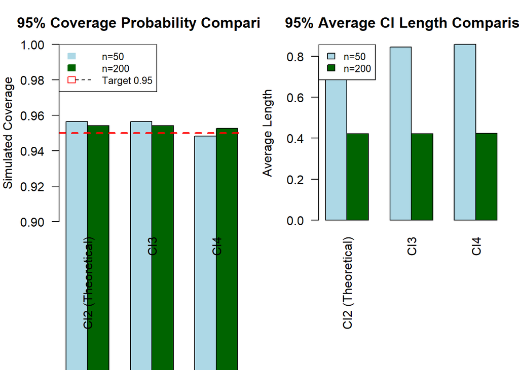

```r
coverage_n50 <- results_N50$alpha_0.05$Coverage
length_n50 <- results_N50$alpha_0.05$Avg_Length

coverage_n200 <- results_N200$alpha_0.05$Coverage
length_n200 <- results_N200$alpha_0.05$Avg_Length

coverage_data <- data.frame(
  Method = c("CI2 (Theoretical)", "CI3", "CI4"),
  Coverage_n50 = coverage_n50,
  Coverage_n200 = coverage_n200
)

length_data <- data.frame(
  Method = c("CI2 (Theoretical)", "CI3", "CI4"),
  Length_n50 = length_n50,
  Length_n200 = length_n200
)

par(mfrow = c(1, 2), mar = c(10, 4, 3, 1))

barplot(
  t(coverage_data[, -1]),
  beside = TRUE,
  main = "95% Coverage Probability Comparison",
  ylab = "Simulated Coverage",
  ylim = c(0.9, 1.0),
  col = c("lightblue", "darkgreen"),
  names.arg = coverage_data$Method,
  las = 2
)

abline(h = 0.95, col = "red", lty = 2, lwd = 2)
legend("topleft", legend = c("n=50", "n=200", "Target 0.95"),
       fill = c("lightblue", "darkgreen", NA),
       border = c("lightblue", "darkgreen", "red"),
       lty = c(NA, NA, 2), cex = 0.8)

barplot(
  t(length_data[, -1]),
  beside = TRUE,
  main = "95% Average CI Length Comparison",
  ylab = "Average Length",
  col = c("lightblue", "darkgreen"),
  names.arg = length_data$Method,
  las = 2
)
legend("topleft", legend = c("n=50", "n=200"),
       fill = c("lightblue", "darkgreen"), cex = 0.8)
```